# Measurement Error Analysis

2023-08-21

### Introduction

```r
# Load required libraries
suppressPackageStartupMessages({
  library("ggplot2")
  library("dplyr")
  library("ggfortify")
  library('tidyverse')
  library('GGally')
  library('MASS')
  library('readr')
  library(lme4)
  library(simex)
})
```

Data Loading

Let’s start by loading the data set created in class.

```r
# Load the dataset from URL
the_URL <- "https://docs.google.com/spreadsheets/d/e/2PACX-1vQDI5oZ54MD4Qm_WDydUAWgRYX1PRWMoOWJCSFN5mZJ6Yf-irKq_n6-7CyPsJ13BoEksusqRUBdcgii/pub?gid=133427610&single=true&output=csv"
class_RTs <- read.csv(the_URL)
```

### Data Preprocessing

Let’s perform data preprocessing tasks such as renaming columns.

```r
# Rename columns for clarity
names(class_RTs) <- c("Timestamp", "ID", "Gender", "Weight", "Handedness", "PRT_1",
                      "PRT_2", "PRT_3", "PRT_4", "PRT_5", "avg_PRT",
                      "Nonpref_RT_ave", "Verbal_memory_score", "Number_memory_score",
                      "Visual_memory_score", "Random_number")
```

### Exploratory Data Analysis

Let’s visualize the data to gain insights into the relationships between variables.

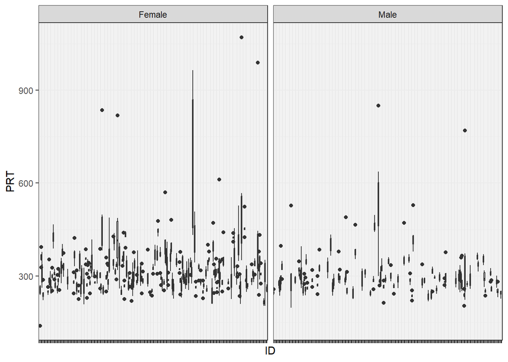

```r
# Gather data for better visualization
gathered <- gather(class_RTs, key = Number, value =  'PRT', "PRT_1",
                   "PRT_2", "PRT_3", "PRT_4", "PRT_5", "avg_PRT")

# Create boxplot by gender
ggplot(gathered, aes(x = ID, y = PRT)) +
  geom_boxplot() +
  facet_wrap(~Gender) +
  theme_bw() +
  theme(axis.text.x = element_blank())
```

### Linear Regression Analysis

We’ll perform linear regression analysis on the data.

#### Model 1: Averaged Reaction Time

Fitting a linear regression model using averaged reaction times.

```r
# Fit a linear regression model
m1 <- lm(avg_PRT ~ Gender, class_RTs)
summary(m1)
```

```
##
## Call:
## lm(formula = avg_PRT ~ Gender, data = class_RTs)
##
## Residuals:
##    Min     1Q Median     3Q    Max
## -99.52 -39.92 -12.62  21.93 544.38
##
## Coefficients:
##             Estimate Std. Error t value Pr(>|t|)
## (Intercept)  315.522      5.316  59.351   <2e-16 ***
## GenderMale    -9.898      9.012  -1.098    0.273
## ---
## Signif. codes:  0 '***' 0.001 '**' 0.01 '*' 0.05 '.' 0.1 ' ' 1
##
## Residual standard error: 64.67 on 225 degrees of freedom
## Multiple R-squared:  0.005333,   Adjusted R-squared:  0.000912
## F-statistic: 1.206 on 1 and 225 DF,  p-value: 0.2732
```

```r
anova(m1)
```

```
## Analysis of Variance Table
##
## Response: avg_PRT
##            Df Sum Sq Mean Sq F value Pr(>F)
## Gender      1   5046  5045.7  1.2063 0.2732
## Residuals 225 941126  4182.8
```

#### Model 2: Individual Reaction Times

```r
# Fit a linear regression model without averaging
m2 <- lm(PRT ~ Gender, gathered)
summary(m2)
```

```
##
## Call:
## lm(formula = PRT ~ Gender, data = gathered)
##
## Residuals:
##     Min      1Q  Median      3Q     Max
## -179.83  -41.98  -13.83   23.20  752.17
##
## Coefficients:
##             Estimate Std. Error t value Pr(>|t|)
## (Intercept)  318.834      2.483 128.397  < 2e-16 ***
## GenderMale   -18.033      4.209  -4.284 1.96e-05 ***
## ---
## Signif. codes:  0 '***' 0.001 '**' 0.01 '*' 0.05 '.' 0.1 ' ' 1
##
## Residual standard error: 74 on 1360 degrees of freedom
## Multiple R-squared:  0.01332,    Adjusted R-squared:  0.01259
## F-statistic: 18.35 on 1 and 1360 DF,  p-value: 1.963e-05
```

```r
anova(m2)
```

```
## Analysis of Variance Table
##
## Response: PRT
##             Df  Sum Sq Mean Sq F value    Pr(>F)
## Gender       1  100500  100500  18.354 1.963e-05 ***
## Residuals 1360 7446809    5476
## ---
## Signif. codes:  0 '***' 0.001 '**' 0.01 '*' 0.05 '.' 0.1 ' ' 1
```

### We’ll fit a mixed effects model to account for individual variability.

```r
# Fit a mixed effects model
lmm1 <- lmer(PRT ~ Gender + (1|ID), data = gathered, REML = F)
null_m <- lmer(PRT ~ (1|ID), data = gathered, REML = F)
summary(lmm1)
```

```
## Linear mixed model fit by maximum likelihood  ['lmerMod']
## Formula: PRT ~ Gender + (1 | ID)
##    Data: gathered
##
##      AIC      BIC   logLik deviance df.resid
##  14942.4  14963.3  -7467.2  14934.4     1358
##
## Scaled residuals:
##     Min      1Q  Median      3Q     Max
## -4.3558 -0.2994 -0.0558  0.1995 11.0901
##
## Random effects:
##  Groups   Name        Variance Std.Dev.
##  ID       (Intercept) 3141     56.05
##  Residual             2352     48.50
## Number of obs: 1362, groups:  ID, 225
##
## Fixed effects:
##             Estimate Std. Error t value
## (Intercept)  318.894      4.902  65.060
## GenderMale   -18.035      8.324  -2.167
##
## Correlation of Fixed Effects:
##            (Intr)
## GenderMale -0.589
```

```r
confint(lmm1)
```

```
## Computing profile confidence intervals ...
```

```
##                 2.5 %     97.5 %
## .sig01       50.59913  62.320967
## .sigma       46.57022  50.561354
## (Intercept) 309.24633 328.542541
## GenderMale  -34.41991  -1.650632
```

```r
anova(null_m, lmm1)
```

```
## Data: gathered
## Models:
## null_m: PRT ~ (1 | ID)
## lmm1: PRT ~ Gender + (1 | ID)
##        npar   AIC   BIC  logLik deviance  Chisq Df Pr(>Chisq)
## null_m    3 14945 14961 -7469.5    14939
## lmm1      4 14942 14963 -7467.2    14934 4.6461  1    0.03112 *
## ---
## Signif. codes:  0 '***' 0.001 '**' 0.01 '*' 0.05 '.' 0.1 ' ' 1
```

### Measurement Error Analysis

We’ll analyze measurement errors using the provided dataset.

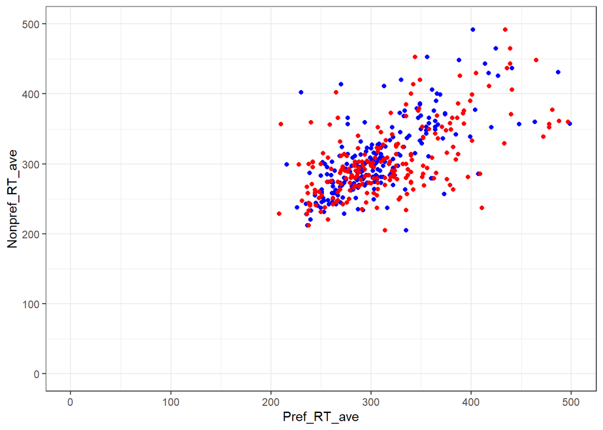

```r
# Load the dataset again for measurement error analysis
dd <- read.csv(the_URL)

# Preprocess the data
names(dd) <- c("Timestamp", "ID", "Gender", "Weight", "Handedness", "PRT_1",
               "PRT_2", "PRT_3", "PRT_4", "PRT_5", "Pref_RT_ave",
               "Nonpref_RT_ave", "Verbal_memory_score", "Number_memory_score",
               "Visual_memory_score", "Random_number")

# Filter out data for analysis
dd_filtered <- dd %>%
  filter(Pref_RT_ave >  50 & Pref_RT_ave < 500)

# Create a scatter plot for measurement error
ggplot(dd_filtered, aes(x = Pref_RT_ave, y = Nonpref_RT_ave)) +
  geom_point(color = 'blue') +
  geom_point(data = dd_filtered, mapping = aes(x = PRT_1, y = Nonpref_RT_ave), color = 'red') +
  xlim(c(0,500)) +
  ylim(c(0,500)) +
  theme_bw()
```

### SIMEX Analysis

We’ll perform SIMEX analysis to account for measurement errors in regression.

```r
# Fit linear regression for SIMEX analysis
r.lm <- lm(Nonpref_RT_ave ~ Pref_RT_ave, dd_filtered, x= TRUE)

# Estimate the error variance
temp <- dplyr::select(dd_filtered,
                      PRT_1,
                      PRT_2,
                      PRT_3,
                      PRT_4,
                      PRT_5)
error_var <- sum((temp - rowMeans(temp))^2) / (nrow(temp)*4) / 5

# Perform SIMEX analysis
measurement.error <- sqrt(error_var)
lambda <- seq(0.1, 2, 0.1)
B <- 50
r.simex <- simex(r.lm, SIMEXvariable = "Pref_RT_ave",
                 measurement.error = measurement.error, lambda = lambda,
                 B = B, fitting.method = 'quadratic')
```

### Conclusion

In this analysis, we explored measurement error analysis using the provided dataset. We performed data loading, preprocessing, exploratory data analysis, linear regression, mixed effects modeling, and SIMEX analysis. The document demonstrates how to handle measurement errors and perform various statistical analyses to gain insights from the data.